# Case Study: RNA-Seq Differential Analysis (basal ganglia)

Chinmay Shukla, Alejandro Reyes, Patrick Kimes

October 30, 2018

# 1 Summary

The objective of this document is benchmark methods to control FDR in the context of differential gene expression.

The data consists of 20 samples from two regions of the human basal ganglia, the nucleus accumbens and the putamen, from the GTEx project. Shortly, samples were downloaded using the *Short Read Archive Toolkit* and mapped to the human reference genome version GRCh38 using *STAR v2.4.2a*. *htseq-count* was used to tabulate the number of uniquely mapping reads for each gene. We used *DESeq2* to format the data into a *DESeqDataSet* object.

# 2 Workspace Setup

```r
library(dplyr)
library(ggplot2)
library(DESeq2)
library(SummarizedBenchmark)
library(BiocParallel)

## load helper functions
for (f in list.files("../R", "\\.(r|R)$", full.names = TRUE)) {
    source(f)
}

## project data/results folders
datdir <- "data"
resdir <- "results"
sbdir <- "../../results/RNAseq"
dir.create(datdir, showWarnings = FALSE)
dir.create(resdir, showWarnings = FALSE)
dir.create(sbdir, showWarnings = FALSE)

## intermediary files we create below
count_file <- file.path(resdir, "brain-counts.rds")
result_file <- file.path(resdir, "brain-results.rds")
bench_file <- file.path(sbdir, "brain-benchmark.rds")
bench_file_uninf <- file.path(sbdir, "brain-uninf-benchmark.rds")

## set up parallel backend
cores <- as.numeric(Sys.getenv("SLURM_NTASKS"))
multicoreParam <- SerialParam()
```

# 3 Data Preparation

We download the DESeqDataSet object from zenodo that contains the gene level counts for GTEx samples.

```r
if (!file.exists(count_file)) {
    download.file("https://zenodo.org/record/1475409/files/rnaseq-brain-counts.rds?download=1", destfile = count_file)
}
dsd <- readRDS(count_file)
```

# 4 Data Analysis

## 4.1 Differential Testing

```r
if (file.exists(result_file)) {
    res <- readRDS(result_file)
} else {
    dds <- DESeq(dsd, parallel = TRUE, BPPARAM = multicoreParam)
    res <- results(dds, independentFiltering = FALSE) %>%
        as.data.frame() %>%
        na.omit() %>%
        dplyr::select(pvalue, baseMean, log2FoldChange, lfcSE, stat) %>%
        dplyr::rename(pval = pvalue,
                      ind_covariate = baseMean,
                      effect_size = log2FoldChange,
                      SE = lfcSE,
                      test_statistic = stat)
    saveRDS(res, file = result_file)
}
```

Add random (uninformative) covariate.

```r
set.seed(83750)
res$rand_covar <- rnorm(nrow(res))
```

## 4.2 Covariate Diagnostics

In RNA-seq differential expression analysis, it is very well established that the mean expression is an informative covariate that is independent under the null and that can be used to increase power while keeping FDR control.

### 4.2.1 Mean Counts

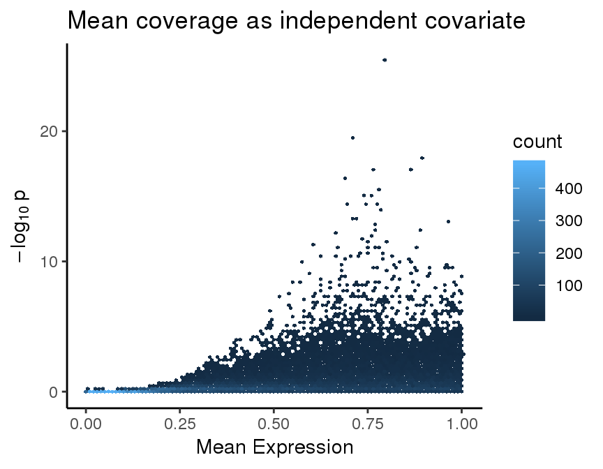

```r
rank_scatter(res, pvalue = "pval", covariate = "ind_covariate") +
    ggtitle("Mean coverage as independent covariate") +
    xlab("Mean Expression")
```

We noticed some discreteness in the distribution of p-values towards values close to 1 that was particularly pronounced in the first covariate bin. The overall distribution of p-values could violate some of the assumptions of the FDR control methods.

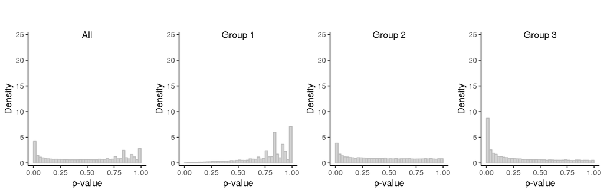

```r
strat_hist(res, pvalue = "pval",
           covariate = "ind_covariate", maxy = 25)
```

This discreteness, however, corresponded to genes with very low expression values. For example, there were 17024 genes with less than an average of 1 read across the 20 samples. The distribution of p-values looked much better when removing these very lowly expressed genes.

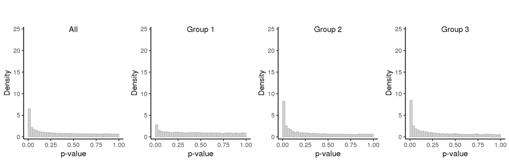

```r
res <- dplyr::filter(res, ind_covariate >= 1)
strat_hist(res, pvalue = "pval",
           covariate = "ind_covariate", maxy = 25)
```

### 4.2.2 Random

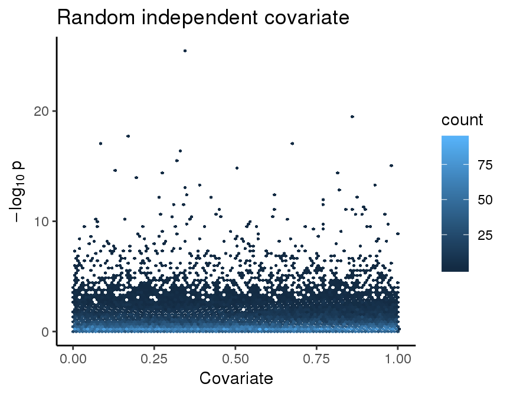

```r
rank_scatter(res, pvalue = "pval", covariate = "rand_covar") +
    ggtitle("Random independent covariate")
```

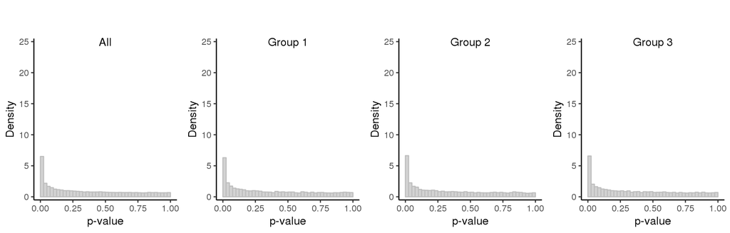

```r
strat_hist(res, pvalue = "pval",
           covariate = "rand_covar", maxy = 25)
```

## 4.3 Multiple-Testing Correction - mean

We use the common `BenchDesign` with the set of multiple testing correction methods already included. We also add in Scott’s FDR Regression (both `nulltype = "empirical"` and `nulltype = "theoretical"`) since our test statistics are approximately t-distributed.

```r
if (file.exists(bench_file)) {
    sb <- readRDS(bench_file)
} else {
    bd <- initializeBenchDesign()

    bd <- addBMethod(bd, "fdrreg-t",
                     FDRreg::FDRreg,
                     function(x) { x$FDR },
                     z = test_statistic,
                     features = model.matrix( ~  splines::bs(ind_covariate, df = 3) - 1),
                     nulltype = 'theoretical',
                     control = list(lambda = 0.01))

   bd <- addBMethod(bd, "fdrreg-e",
                     FDRreg::FDRreg,
                     function(x) { x$FDR },
                     z = test_statistic,
                     features = model.matrix( ~  splines::bs(ind_covariate, df = 3) - 1),
                     nulltype = 'empirical',
                     control = list(lambda = 0.01))

    sb <- buildBench(bd, data = res, ftCols = "ind_covariate")
    saveRDS(sb, file = bench_file)
}
```

## 4.4 Benchmark Metrics - mean

```r
assayNames(sb) <- "qvalue"
sb <- addDefaultMetrics(sb)
estimatePerformanceMetrics(sb, alpha = 0.05, tidy = TRUE) %>%
    filter(performanceMetric == "rejections") %>%
    select(blabel, performanceMetric, alpha, value) %>%
    mutate(n = nrow(sb), prop = round(value / n, 3)) %>%
    arrange(desc(value)) %>%
    as_tibble() %>%
    print(n = 40)
```

```
## # A tibble: 23 x 6
##    blabel     performanceMetric alpha value     n  prop
##    <chr>      <chr>             <dbl> <dbl> <int> <dbl>
##  1 ashq       rejections         0.05  6647 30374 0.219
##  2 unadjusted rejections         0.05  6595 30374 0.217
##  3 lfdr       rejections         0.05  3811 30374 0.125
##  4 adapt-glm  rejections         0.05  3750 30374 0.123
##  5 fdrreg-t   rejections         0.05  3664 30374 0.121
##  6 bl-df02    rejections         0.05  3336 30374 0.11
##  7 bl-df03    rejections         0.05  3262 30374 0.107
##  8 bl-df05    rejections         0.05  3251 30374 0.107
##  9 bl-df04    rejections         0.05  3247 30374 0.107
## 10 qvalue     rejections         0.05  3204 30374 0.105
## 11 ihw-a04    rejections         0.05  2766 30374 0.091
## 12 ihw-a06    rejections         0.05  2763 30374 0.091
## 13 ihw-a07    rejections         0.05  2756 30374 0.091
## 14 ihw-a10    rejections         0.05  2751 30374 0.091
## 15 ihw-a03    rejections         0.05  2745 30374 0.09
## 16 ihw-a08    rejections         0.05  2740 30374 0.09
## 17 ihw-a09    rejections         0.05  2739 30374 0.09
## 18 ihw-a05    rejections         0.05  2734 30374 0.09
## 19 ihw-a01    rejections         0.05  2730 30374 0.09
## 20 ihw-a02    rejections         0.05  2730 30374 0.09
## 21 bh         rejections         0.05  2516 30374 0.083
## 22 fdrreg-e   rejections         0.05   288 30374 0.009
## 23 bonf       rejections         0.05   284 30374 0.009
```

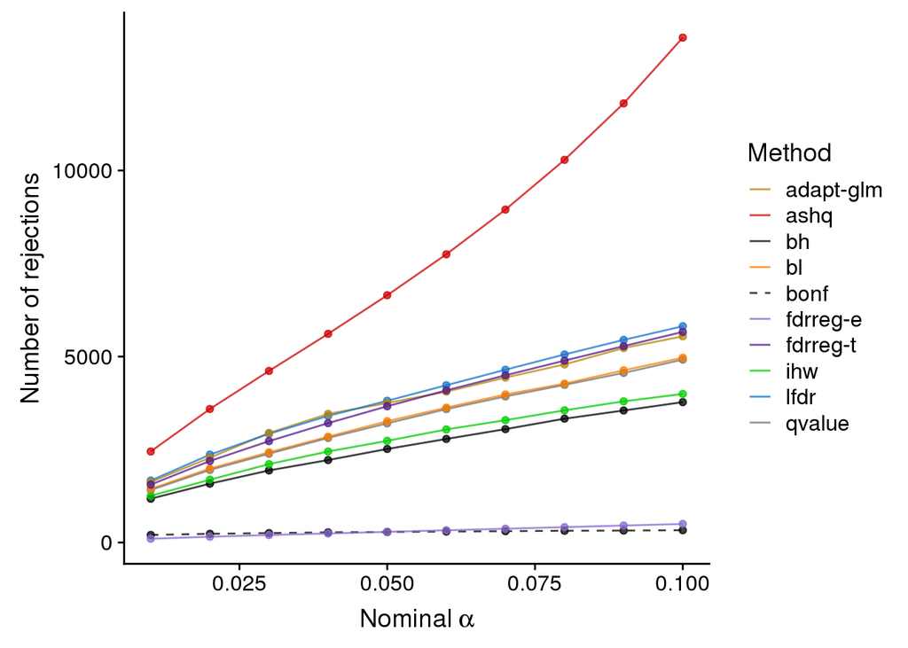

```r
rejections_scatter(sb, supplementary = FALSE)
```

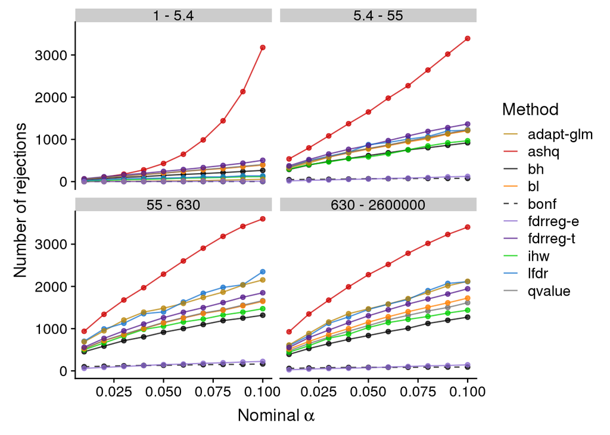

```r
rejection_scatter_bins(sb, covariate = "ind_covariate",
                       bins = 4, supplementary = FALSE)
```

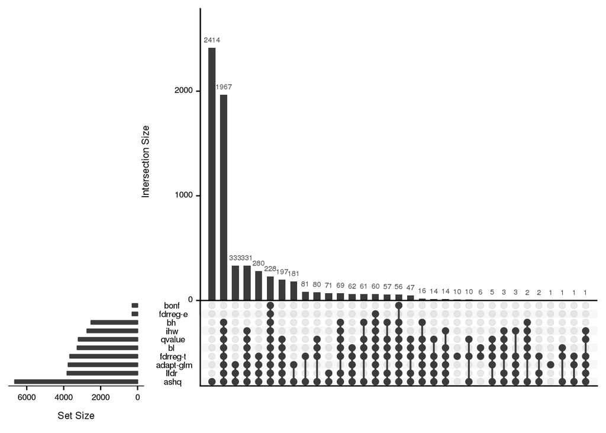

```r
plotFDRMethodsOverlap(sb, alpha = 0.05, nsets = ncol(sb),
                      order.by = "freq", decreasing = TRUE,
                      supplementary = FALSE)
```

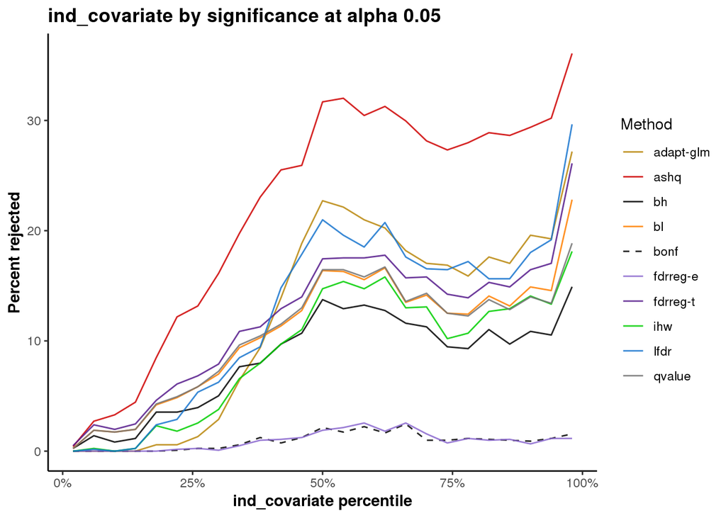

```r
covariateLinePlot(sb, alpha = 0.05, covname = "ind_covariate")
```

## 4.5 Multiple-Testing Correction - random

We use the common `BenchDesign` with the set of multiple testing correction methods already included. We also add in Scott’s FDR Regression (both `nulltype = "empirical"` and `nulltype = "theoretical"`) since our test statistics are approximately t-distributed.

```r
if (file.exists(bench_file_uninf)) {
    sb <- readRDS(bench_file_uninf)
} else {
    bd <- initializeBenchDesign()

    bd <- addBMethod(bd, "fdrreg-t",
                     FDRreg::FDRreg,
                     function(x) { x$FDR },
                     z = test_statistic,
                     features = model.matrix( ~  splines::bs(ind_covariate, df = 3) - 1),
                     nulltype = 'theoretical',
                     control = list(lambda = 0.01))

   bd <- addBMethod(bd, "fdrreg-e",
                     FDRreg::FDRreg,
                     function(x) { x$FDR },
                     z = test_statistic,
                     features = model.matrix( ~  splines::bs(ind_covariate, df = 3) - 1),
                     nulltype = 'empirical',
                     control = list(lambda = 0.01))

    res <- res %>% dplyr::mutate(ind_covariate = rand_covar)
    sb <- buildBench(bd, data = res, ftCols = "ind_covariate")
    saveRDS(sb, file = bench_file_uninf)
}
```

## 4.6 Benchmark Metrics - random

```r
assayNames(sb) <- "qvalue"
sb <- addDefaultMetrics(sb)
estimatePerformanceMetrics(sb, alpha = 0.05, tidy = TRUE) %>%
    filter(performanceMetric == "rejections") %>%
    select(blabel, performanceMetric, alpha, value) %>%
    mutate(n = nrow(sb), prop = round(value / n, 3)) %>%
    arrange(desc(value)) %>%
    as_tibble() %>%
    print(n = 40)
```

```
## # A tibble: 23 x 6
##    blabel     performanceMetric alpha value     n  prop
##    <chr>      <chr>             <dbl> <dbl> <int> <dbl>
##  1 ashq       rejections         0.05  6647 30374 0.219
##  2 unadjusted rejections         0.05  6595 30374 0.217
##  3 fdrreg-t   rejections         0.05  3594 30374 0.118
##  4 bl-df02    rejections         0.05  3297 30374 0.109
##  5 lfdr       rejections         0.05  3273 30374 0.108
##  6 bl-df03    rejections         0.05  3206 30374 0.106
##  7 qvalue     rejections         0.05  3204 30374 0.105
##  8 bl-df04    rejections         0.05  3192 30374 0.105
##  9 bl-df05    rejections         0.05  3191 30374 0.105
## 10 adapt-glm  rejections         0.05  3146 30374 0.104
## 11 ihw-a10    rejections         0.05  2521 30374 0.083
## 12 ihw-a09    rejections         0.05  2520 30374 0.083
## 13 ihw-a06    rejections         0.05  2519 30374 0.083
## 14 ihw-a07    rejections         0.05  2519 30374 0.083
## 15 bh         rejections         0.05  2516 30374 0.083
## 16 ihw-a01    rejections         0.05  2516 30374 0.083
## 17 ihw-a05    rejections         0.05  2515 30374 0.083
## 18 ihw-a08    rejections         0.05  2503 30374 0.082
## 19 ihw-a03    rejections         0.05  2491 30374 0.082
## 20 ihw-a04    rejections         0.05  2484 30374 0.082
## 21 ihw-a02    rejections         0.05  2466 30374 0.081
## 22 bonf       rejections         0.05   284 30374 0.009
## 23 fdrreg-e   rejections         0.05   283 30374 0.009
```

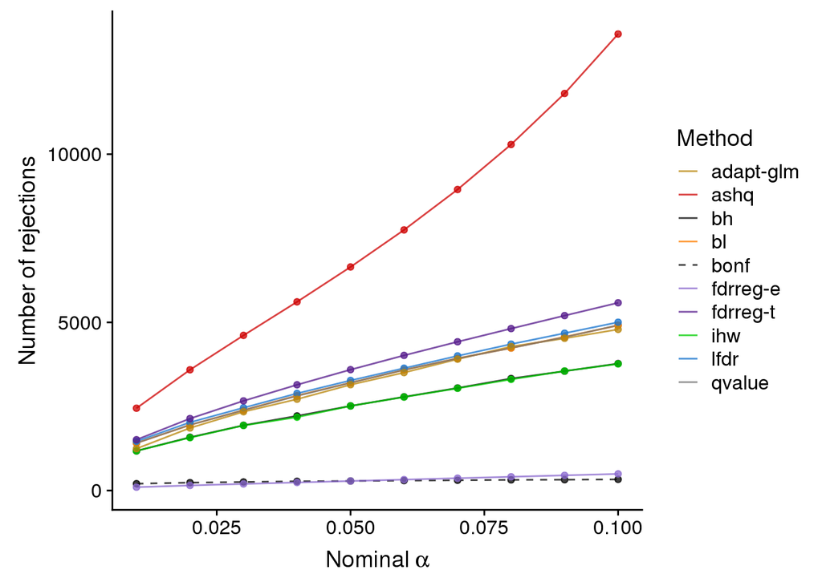

```r
rejections_scatter(sb, supplementary = FALSE)
```

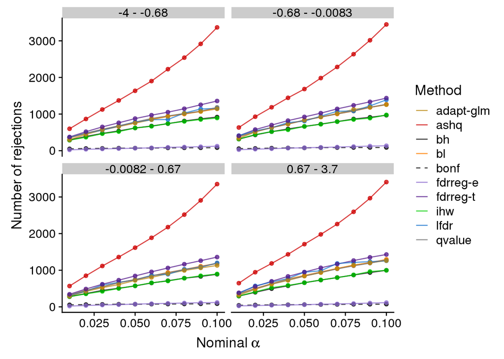

```r
rejection_scatter_bins(sb, covariate = "ind_covariate",
                       bins = 4, supplementary = FALSE)
```

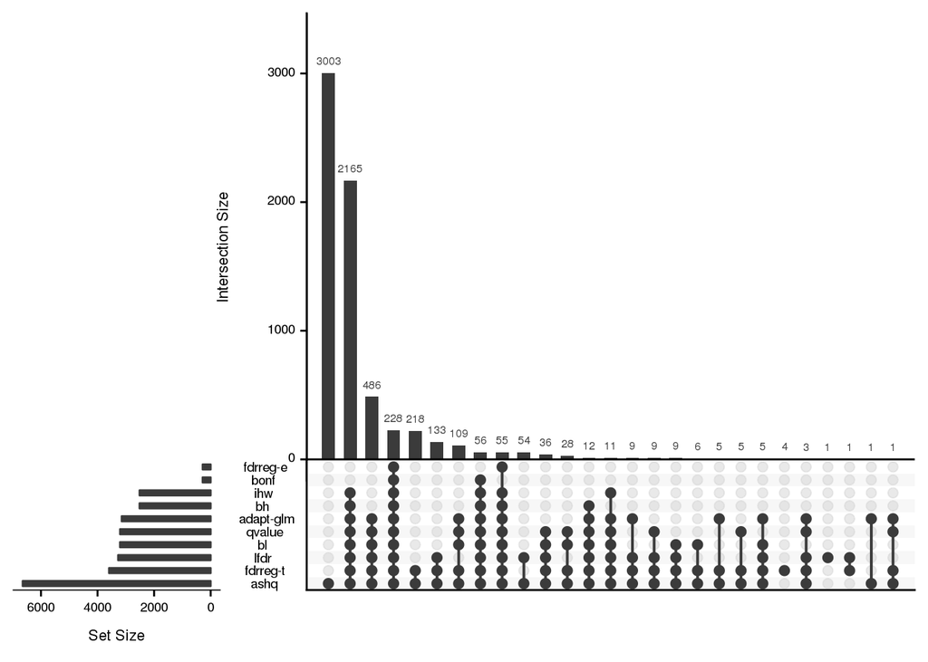

```r
plotFDRMethodsOverlap(sb, alpha = 0.05, nsets = ncol(sb),
                      order.by = "freq", decreasing = TRUE,
                      supplementary = FALSE)
```

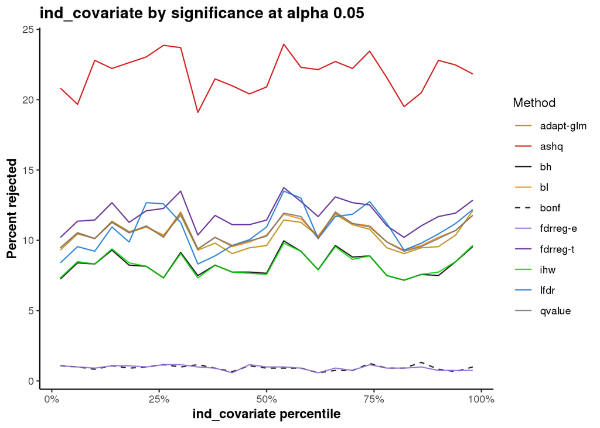

```r
covariateLinePlot(sb, alpha = 0.05, covname = "ind_covariate")
```

# 5 Covariate comparison

Here we compare the method ranks for the different covariates at alpha = 0.10.

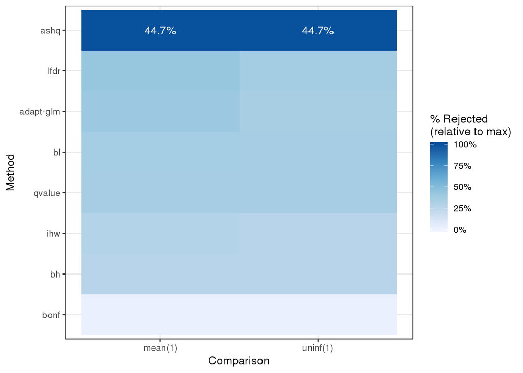

```r
plotMethodRanks(c(bench_file, bench_file_uninf),
                colLabels = c("mean", "uninf"),
                alpha = 0.10, xlab = "Comparison")
```